# R Notebook - Analytics Zone

Group YoutubeFinder

# Analytics of the Video Metadata datasets

> This RMarkdown represents the Analytics Zone and consists of the analysis that has been done in the Video Metadata files. **Obs**: All the analysis performed throughout this R markdown is better explained in the written document. There it is detailed the motivations and reasoning for each process and section.

# Import libraries

```r
library("readtext")
library("jsonlite")
library("rjson")
library("parallel")
library("ggplot2")
library("reshape2")
library("dplyr")
library("tidyr")
library("cld3")
library("textcat")
library("httr")
library('data.table')
library("purrr")
library("rlist")
library("FactoMineR")
library("mice")
library("naniar")
library("PCAmixdata")
library("plyr")
library("RSQLite")
library("xlsx")
library("BBmisc")

root_path <- "/Users/daniel/LocalFiles for TFM/"
setwd(root_path)
```

# Extra: Save the files in a permanent data in order to be easily readable

```r
#To almost mimic the functionality of store or stores in R, you can do the following. Use save(x,y,z,file="Permdata") to save permanent objects in "permdata". When you exit R, do not save the workspace. Then all temporary objects will disappear. In your .Rprofile put the command load("Permdata") so that the next time you invoke R the permanent objects will be available.
save(json_list,df_language_fulltitle,df_language_fulltitle_textcat, sorted_json_list3,df_json_metadata, df_json_metadata_enrich, res.pcamix,res.pca,videos_words,dataframeLikes,file="Permanentdata")
```

```r
# Load the saved data. Warning: the setwd() must be pointing to the folder where the file is placed.
load(paste0(root_path,"Permanentdata"))
```

```r
# This is not executed in the knitr part because it was previously saved in the permanent data. This process is slow, takes approximately 1h30min to create the json_list object, even using parallel library

# This is a temporary solution to read the files from local repository
# Later they should be read from HDFS
# File location: https://drive.google.com/file/d/1ERz6um0Wy2Qzjh76AlHZ70dt1Dc26JZJ/view?usp=sharing
# Download and save in local machine. Replace the root_path directory.

#Reading the files using parallel (takes on average 1h30min to finish)
cl <- makeCluster(detectCores() - 1)
#Parallel not working in RStudio https://github.com/rstudio/rstudio/issues/6692
json_files<-list.files(path =paste0(root_path,"Files/video-content/"),pattern="*.json",full.names = TRUE)
json_list<-parLapply(cl,json_files,function(x) rjson::fromJSON(file=x,method = "R"))
stopCluster(cl)

class(json_list)
# list
length(json_list)
# 72068
lengths(json_list)
# Each list with 64 elements
```

# Calculating **Missing Values** for the main elements in video metadata

```r
#Function works only for list type variables
function_is_null <- function(x, var = " "){
  len <- length(x)
  null = 0
  for(i in 1:len){
    if (is.null(x[[i]][[var]])){
      null <- null + 1
    }
  }
  cat(var,i)
  return(null)
}

null_dislike_count <- function_is_null(json_list,var = "dislike_count")
```

```
dislike_count 72068
```

```r
null_like_count <- function_is_null(json_list,var = "like_count")
```

```
like_count 72068
```

```r
null_id_count_count <- function_is_null(json_list,var = "id")
```

```
id 72068
```

```r
null_channel_id_count <- function_is_null(json_list,var = "channel_id")
```

```
channel_id 72068
```

```r
null_categories_count <- function_is_null(json_list,var = "categories")
```

```
categories 72068
```

```r
null_description_count <- function_is_null(json_list,var = "description")
```

```
description 72068
```

```r
null_webpage_url_count <- function_is_null(json_list,var = "webpage_url")
```

```
webpage_url 72068
```

```r
null_upload_date_count <- function_is_null(json_list,var = "upload_date")
```

```
upload_date 72068
```

```r
null_average_rating_count <- function_is_null(json_list,var = "average_rating")
```

```
average_rating 72068
```

```r
null_view_count <- function_is_null(json_list,var = "view_count")
```

```
view_count 72068
```

```r
null_thumbnail_count <- function_is_null(json_list,var = "thumbnail")
```

```
thumbnail 72068
```

```r
null_duration_count <- function_is_null(json_list,var = "duration")
```

```
duration 72068
```

```r
null_fulltitle_count <- function_is_null(json_list,var = "fulltitle")
```

```
fulltitle 72068
```

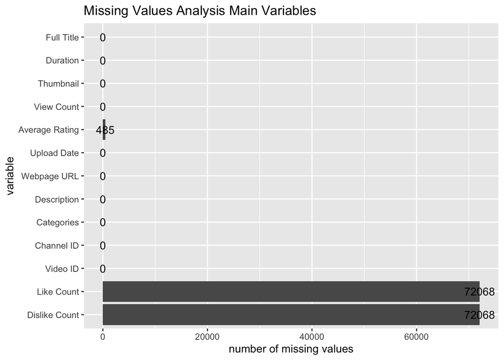

```r
col_names <- c("Dislike Count","Like Count","Video ID", "Channel ID","Categories","Description", "Webpage URL",
               "Upload Date","Average Rating", "View Count","Thumbnail","Duration","Full Title")
df <- data.frame(null_dislike_count,null_like_count,null_id_count_count,null_channel_id_count,null_categories_count,null_description_count,null_webpage_url_count,
          null_upload_date_count,null_average_rating_count,null_view_count,null_thumbnail_count,null_duration_count,null_fulltitle_count)
colnames(df) <- col_names

# Plotting the results
cd274 <- melt(df[, 1:ncol(df)])
ggplot(cd274, aes(x = variable, y = value)) + geom_bar(stat = "identity",position = "dodge") +
  labs(x='variable', y="number of missing values", title='Missing Values Analysis Main Variables') +
  coord_flip() + geom_text(aes(label=value))
```

# Language Detection Analysis

## Testing CLD3 package

```r
#Function works only for list type variables
fun_transf_df_language_detection_cld3 <- function(x,var1 = " ",var2=" "){
  len <- length(x)
  for(i in 1:len){
    text1<-x[[i]][[var1]]
    text2<-x[[i]][[var2]]
    combinedText<-paste(text1,text2)
    language <- cld3::detect_language(combinedText)
    if(i == 1){
      dataframe <- data.frame(combinedText,language)
      col <- c("Text","Language_Detected")
      colnames(dataframe) <- col
    } else{
      dataframe[nrow(dataframe)+1,] <- cbind(combinedText,language)
    }
  }
  return(dataframe)
}

df_language_fulltitle <- fun_transf_df_language_detection_cld3(json_list,"fulltitle","description")
summary_cld3 <- df_language_fulltitle %>%
  group_by(Language_Detected) %>%
  dplyr::summarize(count=n()) %>% arrange(desc(count))
```

## Testing Texcat package

```r
fun_transf_df_language_detection_textcat <- function(x,var1 = " ",var2=" "){
  len <- length(x)
  for(i in 1:len){
    text1<-x[[i]][[var1]]
    text2<-x[[i]][[var2]]
    combinedText<-paste(text1,text2)
    language <- textcat::textcat(combinedText,p=textcat::TC_char_profiles)
    if(i == 1){
      dataframe <- data.frame(combinedText,language)
      col <- c("Text","Language_Detected")
      colnames(dataframe) <- col
    } else{
      dataframe[nrow(dataframe)+1,] <- cbind(combinedText,language)
    }
  }
  return(dataframe)
}

df_language_fulltitle_textcat <- fun_transf_df_language_detection_textcat(json_list,"fulltitle","description")
summary_textcat <- df_language_fulltitle_textcat %>%
  group_by(Language_Detected) %>%
  dplyr::summarize(count=n()) %>% arrange(desc(count))
```

## Testing the results using a few random samples (visual checking against the original data)

```r
# Testing the results
sample <- sample(1:length(json_list),round(0.0001*length(json_list)))
for(i in 1:length(sample)){
  if(i == 1){
      test_result <- data.frame(sample[i],json_list[[sample[i]]][["description"]])
      col <- c("RowId","Text")
      colnames(test_result) <- col
    } else{
      test_result[nrow(test_result)+1,] <- cbind(sample[i],json_list[[sample[i]]][["description"]])
    }
}
```

# Analysis to find out how the datasets are balanced

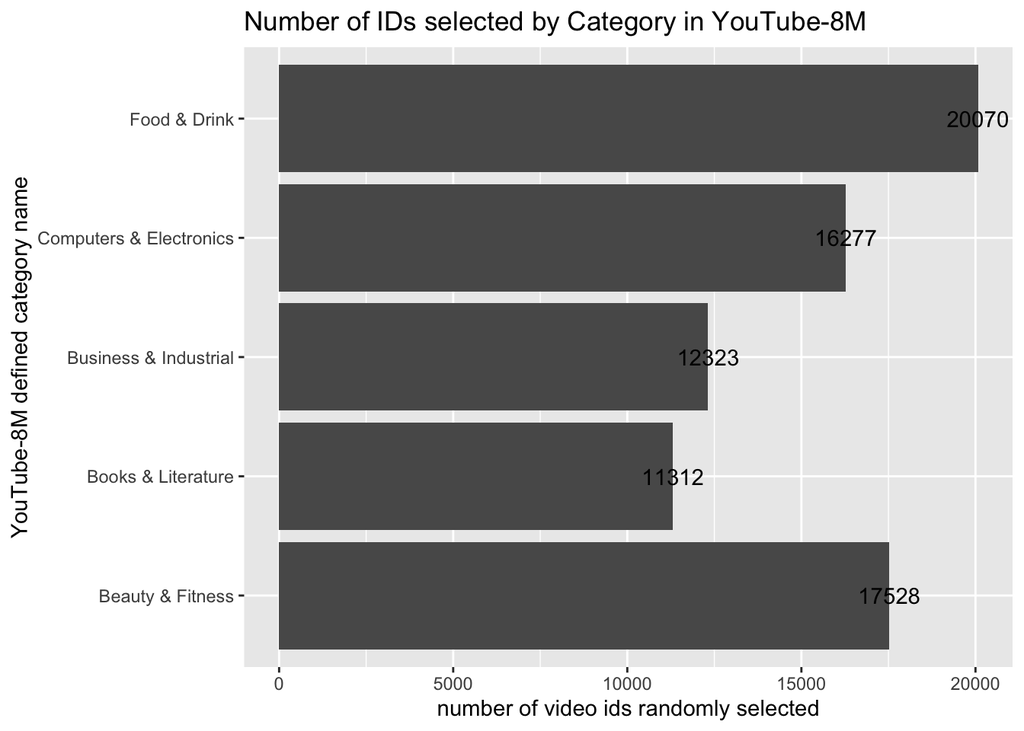

```r
definitive_ids <- read.delim(paste0(root_path,"Files/definitive_videoids_updated_20200901.txt"),header=FALSE,sep=" ",dec=" ")
beauty_fitness <- read.delim(paste0(root_path,"Files/Beauty_Fitness.txt"),header=FALSE,sep=" ",dec=" ")
books_literature <- read.delim(paste0(root_path,"Files/Books_Literature.txt"),header=FALSE,sep=" ",dec=" ")
business_industrial <- read.delim(paste0(root_path,"Files/Business_Industrial.txt"),header=FALSE,sep=" ",dec=" ")
computers_electronics <- read.delim(paste0(root_path,"Files/Computers_Electronics.txt"),header=FALSE,sep=" ",dec=" ")
food_drink <- read.delim(paste0(root_path,"Files/Food_Drink.txt"),header=FALSE,sep=" ",dec=" ")

beauty_fitness$check<- ifelse(beauty_fitness$V1 %in% definitive_ids$V1,"Yes", "No")
new_beauty_fitness <- beauty_fitness %>% filter(check == "Yes")

books_literature$check<- ifelse(books_literature$V1 %in% definitive_ids$V1,"Yes", "No")
new_books_literature <- books_literature %>% filter(check == "Yes")

business_industrial$check<- ifelse(business_industrial$V1 %in% definitive_ids$V1,"Yes", "No")
new_business_industrial <- business_industrial %>% filter(check == "Yes")

computers_electronics$check<- ifelse(computers_electronics$V1 %in% definitive_ids$V1,"Yes", "No")
new_computers_electronics <- computers_electronics %>% filter(check == "Yes")

food_drink$check<- ifelse(food_drink$V1 %in% definitive_ids$V1,"Yes", "No")
new_food_drink <- food_drink %>% filter(check == "Yes")

result_balance<-data.frame(nrow(new_beauty_fitness),nrow(new_books_literature),nrow(new_business_industrial),nrow(new_computers_electronics),nrow(new_food_drink))
colnames(result_balance) <- c("Beauty & Fitness","Books & Literature", "Business & Industrial","Computers & Electronics","Food & Drink")
#View(result_balance)

# Check how many Ids are present in all categories and which are exclusive per category
# Attempt 1: not good therefore not used
'%notin%' <- Negate('%in%')
definitive_ids$check_all <- ifelse((definitive_ids$V1 %in% food_drink$V1 &
                                               definitive_ids$V1 %in% computers_electronics$V1 &
                                               definitive_ids$V1 %in% business_industrial$V1 &
                                               definitive_ids$V1 %in% books_literature$V1 &
                                               definitive_ids$V1 %in% beauty_fitness$V1),"Yes", "No")

definitive_ids$exclusive_fooddrink <- ifelse(definitive_ids$V1 %in% food_drink$V1 &
                                               definitive_ids$V1 %notin% computers_electronics$V1 &
                                               definitive_ids$V1 %notin% business_industrial$V1 &
                                               definitive_ids$V1 %notin% books_literature$V1 &
                                               definitive_ids$V1 %notin% beauty_fitness$V1,"Yes", "No")

definitive_ids$exclusive_compelect<- ifelse(definitive_ids$V1 %notin% food_drink$V1 &
                                               definitive_ids$V1 %in% computers_electronics$V1 &
                                               definitive_ids$V1 %notin% business_industrial$V1 &
                                               definitive_ids$V1 %notin% books_literature$V1 &
                                               definitive_ids$V1 %notin% beauty_fitness$V1,"Yes", "No")

definitive_ids$exclusive_busind<- ifelse(definitive_ids$V1 %notin% food_drink$V1 &
                                               definitive_ids$V1 %notin% computers_electronics$V1 &
                                               definitive_ids$V1 %in% business_industrial$V1 &
                                               definitive_ids$V1 %notin% books_literature$V1 &
                                               definitive_ids$V1 %notin% beauty_fitness$V1,"Yes", "No")

definitive_ids$exclusive_bookslit<- ifelse(definitive_ids$V1 %notin% food_drink$V1 &
                                               definitive_ids$V1 %notin% computers_electronics$V1 &
                                               definitive_ids$V1 %notin% business_industrial$V1 &
                                               definitive_ids$V1 %in% books_literature$V1 &
                                               definitive_ids$V1 %notin% beauty_fitness$V1,"Yes", "No")

definitive_ids$exclusive_beautyfit<- ifelse(definitive_ids$V1 %notin% food_drink$V1 &
                                               definitive_ids$V1 %notin% computers_electronics$V1 &
                                               definitive_ids$V1 %notin% business_industrial$V1 &
                                               definitive_ids$V1 %notin% books_literature$V1 &
                                               definitive_ids$V1 %in% beauty_fitness$V1,"Yes", "No")

exclusive_balance<-data.frame(nrow(definitive_ids %>% filter(check_all == "Yes")),
                              nrow(definitive_ids %>% filter(exclusive_fooddrink == "Yes")),
                              nrow(definitive_ids %>% filter(exclusive_compelect == "Yes")),
                              nrow(definitive_ids %>% filter(exclusive_busind == "Yes")),
                              nrow(definitive_ids %>% filter(exclusive_bookslit == "Yes")),
                              nrow(definitive_ids %>% filter(exclusive_beautyfit == "Yes")))
colnames(exclusive_balance) <- c("In All Cats","Food & Drink","Computers & Electronics","Business & Industrial","Books & Literature","Beauty & Fitness")

###
#Attempt 2: good, therefore used

definitive_ids$inbeautyfitness<- ifelse(definitive_ids$V1 %in% beauty_fitness$V1,"Yes", "No")
new_beauty_fitness <- definitive_ids %>% filter(inbeautyfitness == "Yes")

definitive_ids$inbooksliterature<- ifelse(definitive_ids$V1 %in% books_literature$V1,"Yes", "No")
new_books_literature <- definitive_ids %>% filter(inbooksliterature == "Yes")

definitive_ids$inbusinessindustrial<- ifelse(definitive_ids$V1 %in% business_industrial$V1,"Yes", "No")
new_business_industrial <- definitive_ids %>% filter(inbusinessindustrial == "Yes")

definitive_ids$incomputer<- ifelse(definitive_ids$V1 %in% computers_electronics$V1,"Yes", "No")
new_computers_electronics <- definitive_ids %>% filter(incomputer == "Yes")

definitive_ids$infooddrink<- ifelse(definitive_ids$V1 %in% food_drink$V1,"Yes", "No")
new_food_drink <- definitive_ids %>% filter(infooddrink == "Yes")

third_balance_test<-data.frame(nrow(new_beauty_fitness),nrow(new_books_literature),nrow(new_business_industrial),nrow(new_computers_electronics),nrow(new_food_drink))
colnames(third_balance_test) <- c("Beauty & Fitness","Books & Literature", "Business & Industrial","Computers & Electronics","Food & Drink")
#View(third_balance_test)

melted <- melt(third_balance_test[, 1:ncol(third_balance_test)])
ggplot(melted, aes(x = variable, y = value)) + geom_bar(stat = "identity",position = "dodge") +
  labs(x='YouTube-8M defined category name', y="number of video ids randomly selected", title='Number of IDs selected by Category in YouTube-8M') +
  coord_flip() + geom_text(aes(label=value))
```

# Checking the total number of video ids per category from the **Original files in Youtube-8M**

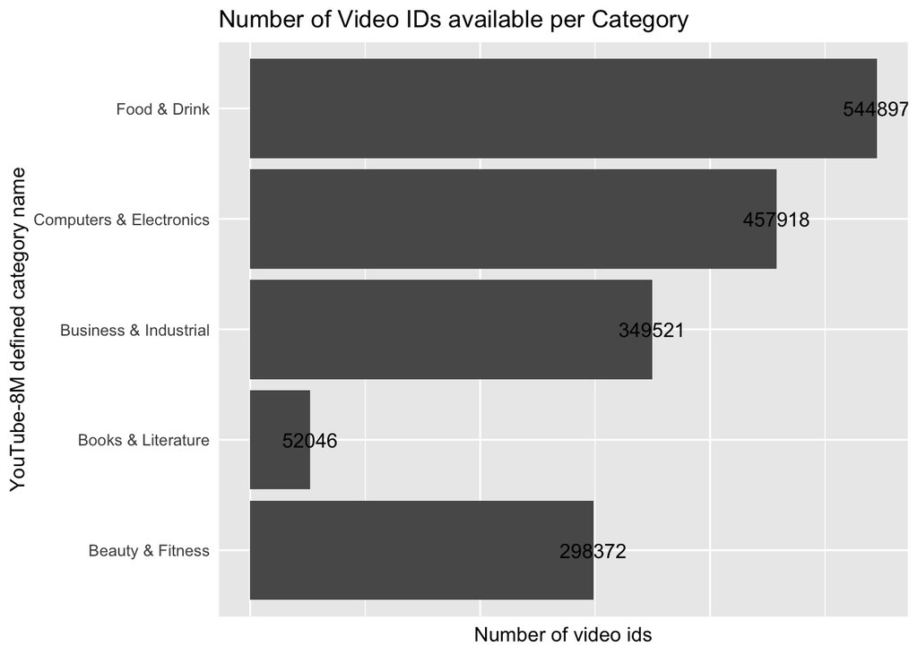

```r
original_datasets_balance<-data.frame(nrow(beauty_fitness),nrow(books_literature),nrow(business_industrial),nrow(computers_electronics),nrow(food_drink))
colnames(original_datasets_balance) <- c("Beauty & Fitness","Books & Literature", "Business & Industrial","Computers & Electronics","Food & Drink")
#View(original_datasets_balance)

melted <- melt(original_datasets_balance[, 1:ncol(original_datasets_balance)])
ggplot(melted, aes(x = variable, y = value)) + geom_bar(stat = "identity",position = "dodge") +
  labs(x='YouTube-8M defined category name', y="Number of video ids", title='Number of Video IDs available per Category') +
  coord_flip() + geom_text(aes(label=value)) +
  theme(axis.text.x = element_blank(),axis.ticks = element_blank())
```

```r
sum(nrow(beauty_fitness),nrow(books_literature),nrow(business_industrial),nrow(computers_electronics),nrow(food_drink))
```

```
[1] 1702754
```

```r
# DISCLAIMER: We've tried but it is not working to open direct from HDFS.
# Parameters
hdfsUri <- "https://10.0.2.15:50470"
fileUri <- "/home/data/video-likes.zip"
readParameter <- "?op=OPEN"
optionnalParameters <- ""
uri <- paste0(hdfsUri, fileUri, readParameter, optionnalParameters)
data <- read.delim(uri)
```

# Analysis on the Video Ids that we obtained Transcripts but we didn’t obtain Metadata

```r
cl <- makeCluster(detectCores() - 1)
json_like_files<-list.files(path =paste0(root_path,"Files/video-likes"),pattern="*.json",full.names = TRUE)
json_like_list<-parLapply(cl,json_like_files,function(x) rjson::fromJSON(file=x,method = "R"))
stopCluster(cl)
#Code to add the id to the list
N <- length(json_like_files)
for (i in 1:N){
  print(i)
  filename <- basename(json_like_files[i]) %>% gsub(pattern = ".json",replacement = "",.)
  names(json_like_list[[i]])[length(json_like_list[[i]])] <- "video_id"
  json_like_list[[i]]$video_id <- filename
}
```

```r
#Transform list into dataframe to be easier to plot
dataframeLikes <- bind_rows(lapply(json_like_list, as.data.frame.list))
dataframeLikes$viewCount <- as.numeric(dataframeLikes$viewCount)
dataframeLikes$likeCount <- as.numeric(dataframeLikes$likeCount)
dataframeLikes$dislikeCount <- as.numeric(dataframeLikes$dislikeCount)
```

```r
#Summary
summary(dataframeLikes)
```

```
   viewCount           likeCount       dislikeCount      favoriteCount
 Min.   :     1012   Min.   :     0   Min.   :     0.0   Length:75835
 1st Qu.:     3354   1st Qu.:    16   1st Qu.:     1.0   Class :character
 Median :     9151   Median :    56   Median :     5.0   Mode  :character
 Mean   :   123681   Mean   :   873   Mean   :    64.9
 3rd Qu.:    33317   3rd Qu.:   234   3rd Qu.:    17.0
 Max.   :622859472   Max.   :981209   Max.   :714221.0
 NA's   :192         NA's   :2096     NA's   :2096
   video_id         commentCount
 Length:75835       Length:75835
 Class :character   Class :character
 Mode  :character   Mode  :character
```

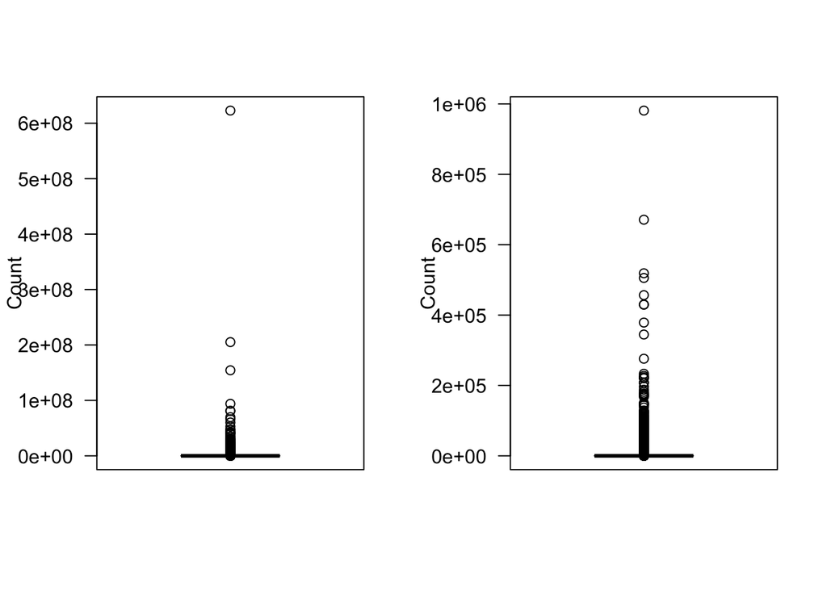

```r
#Boxplot - it does not look good
op<-par(mfrow=c(1,2))

boxplot(dataframeLikes$viewCount, names = "View Count",las = 2, col = "royalblue")
mtext("Count", side = 2, line = 3)

boxplot(dataframeLikes$likeCount, names = "Like Count",las = 2, col = "royalblue")
mtext("Count", side = 2, line = 3)
```

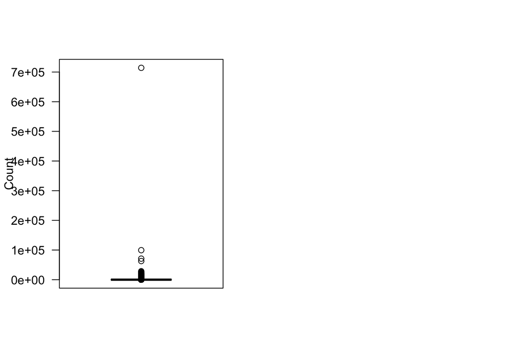

```r
boxplot(dataframeLikes$dislikeCount, names = "Dislike Count",las = 2, col = "royalblue")
mtext("Count", side = 2, line = 3)

par(op)
```

```r
# Check the ids in the transcript files that are not present in the video metadata
transcript_files<-list.files(path =paste0(root_path,"Files/ALL_Transcripts"),pattern="*.txt",full.names = TRUE)
#Get the video ids that have transcript
transcript_video_ids <- data.frame()
for (i in 1:length((transcript_files))){
  filename <- basename(transcript_files[i]) %>% gsub(pattern = ".en.txt",replacement = "",.)
  transcript_video_ids <- rbind(transcript_video_ids,filename)
}
```

```r
json_files<-list.files(path =paste0(root_path,"Files/video-content/"),pattern="*.json",full.names = TRUE)
json_video_ids <- data.frame()
#Get video ids that have video metadata
for (i in 1:length((json_files))){
  filename <- basename(json_files[i]) %>% gsub(pattern = ".info.json",replacement = "",.)
  json_video_ids <- rbind(json_video_ids,filename)
}

#Get the valuesin transcript_video_ids but not in json_video_ids
diff_lists<-setdiff(transcript_video_ids,json_video_ids)
diff_lists <- as.data.frame(diff_lists)

diff_lists$inbeautyfitness<- ifelse(diff_lists$diff_lists %in% beauty_fitness$V1,"Yes", "No")
new_beauty_fitness <- diff_lists %>% filter(inbeautyfitness == "Yes")

diff_lists$inbooksliterature<- ifelse(diff_lists$diff_lists %in% books_literature$V1,"Yes", "No")
new_books_literature <- diff_lists %>% filter(inbooksliterature == "Yes")

diff_lists$inbusinessindustrial<- ifelse(diff_lists$diff_lists %in% business_industrial$V1,"Yes", "No")
new_business_industrial <- diff_lists %>% filter(inbusinessindustrial == "Yes")

diff_lists$incomputer<- ifelse(diff_lists$diff_lists %in% computers_electronics$V1,"Yes", "No")
new_computers_electronics <- diff_lists %>% filter(incomputer == "Yes")

diff_lists$infooddrink<- ifelse(diff_lists$diff_lists %in% food_drink$V1,"Yes", "No")
new_food_drink <- diff_lists %>% filter(infooddrink == "Yes")

diff_lists_balance<-data.frame(nrow(new_beauty_fitness),nrow(new_books_literature),nrow(new_business_industrial),nrow(new_computers_electronics),nrow(new_food_drink))
colnames(diff_lists_balance) <- c("Beauty & Fitness","Books & Literature", "Business & Industrial","Computers & Electronics","Food & Drink")

dat.m <- melt(as.data.table(diff_lists_balance, keep.rownames = "Vars"), id.vars = "Vars")

ggplot(dat.m, aes(x = variable, y = value)) + geom_bar(stat = "identity",position = "dodge") +
  labs(x='YouTube-8M defined category name', y="number of video ids", title='Video IDs with Transcript but without Metadata (per Category)') +
  coord_flip()

#Code to check whether there were videos that we didn't manage to get the like and dislike counts
#video_likes <- read.delim(paste0(root_path,"Files/video-likes/video-likes.txt"),header=FALSE,sep=" ",dec=" ")
#definitive_ids$invideolikes <- ifelse(definitive_ids$V1 %in% video_likes$V1,"Yes", "No")
#new_video_likes <- definitive_ids %>% filter(invideolikes == "No")
#write.table(new_video_likes$V1,file = "video-likes-diff.txt", sep = " ", row.names = FALSE, col.names = FALSE)
```

## Analyse if the issue with missing values in like and dislike has worked out

```r
col_names <- c("Dislike Count","Like Count")
df_fixed_likes <- data.frame(nrow(dataframeLikes[is.na(dataframeLikes$dislikeCount),]),nrow(dataframeLikes[is.na(dataframeLikes$likeCount),]))
colnames(df_fixed_likes) <- col_names

# Plotting the results
cd274 <- melt(as.data.table(df_fixed_likes, keep.rownames = "Vars"), id.vars = "Vars")
ggplot(cd274, aes(x = variable, y = value)) + geom_bar(stat = "identity",position = "dodge") +
  labs(x='variable', y="number of missing values", title='Count of Missing Values for Like and Dislike Count') +
  coord_flip() + geom_text(aes(label=value))
```

[output not shown]

```r
df_videos_without_metadata <- dataframeLikes[dataframeLikes$video_id %in% diff_lists$diff_lists,]
summary(df_videos_without_metadata)
```

# Analysis on the Video Ids that we obtained Transcripts but we didn’t obtain Sentiment Analysis calculation

```r
sentAnalysis <- read.csv(paste0(root_path,"youtubeProjectTFM/src/sentiment_analysis.csv"),sep=",",header = T)
diff_lists_t_sa<-setdiff(transcript_video_ids,sentAnalysis$video_id)
head(sentAnalysis)
head(transcript_video_ids)
diff_lists_t_sa <- as.data.frame(diff_lists_t_sa)

diff_lists_t_sa$inbeautyfitness<- ifelse(diff_lists_t_sa$diff_lists_t_sa %in% beauty_fitness$V1,"Yes", "No")
new_beauty_fitness <- diff_lists_t_sa %>% filter(inbeautyfitness == "Yes")

diff_lists_t_sa$inbooksliterature<- ifelse(diff_lists_t_sa$diff_lists_t_sa %in% books_literature$V1,"Yes", "No")
new_books_literature <- diff_lists_t_sa %>% filter(inbooksliterature == "Yes")

diff_lists_t_sa$inbusinessindustrial<- ifelse(diff_lists_t_sa$diff_lists_t_sa %in% business_industrial$V1,"Yes", "No")
new_business_industrial <- diff_lists_t_sa %>% filter(inbusinessindustrial == "Yes")

diff_lists_t_sa$incomputer<- ifelse(diff_lists_t_sa$diff_lists_t_sa %in% computers_electronics$V1,"Yes", "No")
new_computers_electronics <- diff_lists_t_sa %>% filter(incomputer == "Yes")

diff_lists_t_sa$infooddrink<- ifelse(diff_lists_t_sa$diff_lists_t_sa %in% food_drink$V1,"Yes", "No")
new_food_drink <- diff_lists_t_sa %>% filter(infooddrink == "Yes")

diff_lists_balance_t_sa<-data.frame(nrow(new_beauty_fitness),nrow(new_books_literature),nrow(new_business_industrial),nrow(new_computers_electronics),nrow(new_food_drink))
colnames(diff_lists_balance_t_sa) <- c("Beauty & Fitness","Books & Literature", "Business & Industrial","Computers & Electronics","Food & Drink")

dat.m <- melt(as.data.table(diff_lists_balance_t_sa, keep.rownames = "Vars"), id.vars = "Vars")

ggplot(dat.m, aes(x = variable, y = value)) + geom_bar(stat = "identity",position = "dodge") +
  labs(x='YouTube-8M defined category name', y="number of video ids", title='Video IDs with Transcript but without Sentiment Analysis (per Category)') +
  coord_flip()
```

```r
df_videos_without_sentAnalysis <- dataframeLikes[dataframeLikes$video_id %in% diff_lists_t_sa$diff_lists_t_sa,]
summary(df_videos_without_sentAnalysis)
```

# Defining the global score

# First Technique: PCA

## Attempt 1

> This attempt was not finally successful because the way the data was organized and the formula was executed, was not finally correct because the indicators were not taken into account, only the variables separately. However we left the attempt here.
- It has been tested the PCA for the raw video data alongside sentiment analysis dataframe. To do so, a single dataframe has been built. ### Preparing the data

```r
#Function used to sort the elements inside the list
sentAnalysis <- read.csv(paste0(root_path,"youtubeProjectTFM/src/sentiment_analysis.csv"),sep=",",header = T)

fun_sort <- function(file){
  for(i in 1:length(file)){
    file[[i]] <- file[[i]][sort(names(file[[i]]))]
  }
  return(file)
}

#Library to find out whether there are unique elements in the list. It returned FALSE, which means that the lists have no homogeneity
sorted_json_list2 <- fun_sort(json_list)
sorted_json_list2 %>%
  map(names) %>%
  unique() %>%
  length() == 1
```

```
[1] FALSE
```

```r
# So we need to make the list homogenous, and to do so we found out that the stretched_ratio is one field that is present only in a few lists. So, we remove it.
fun_remove_elements <- function(file,var){
  for(i in 1:length(file)){
    file[[i]] <- list.remove(file[[i]],var)
  }
  return(file)
}
sorted_json_list3 <- fun_remove_elements(sorted_json_list2,'stretched_ratio')

#Now it returned TRUE, so it is homogenous
sorted_json_list3 %>%
  map(names) %>%
  unique() %>%
  length() == 1
```

```
[1] TRUE
```

```r
#However, the functions to transform to dataframe was not working because of difference in the values of each variables.
#So we had to convert the null values and convert all variables to character
convertNullToZero <- function(x){
  len <- length(x)
  for(i in 1:len){
    if (is.null(x[[i]][["_filename"]])){
      x[[i]][["_filename"]] <- NA_character_
    }
    if (is.null(x[[i]][["abr"]])){
      x[[i]][["abr"]] <- NA_character_
    }
    if (is.null(x[[i]][["acodec"]])){
      x[[i]][["acodec"]] <- NA_character_
    }
    if (is.null(x[[i]][["age_limit"]])){
      x[[i]][["age_limit"]] <- NA_character_
    }
    if (is.null(x[[i]][["album"]])){
      x[[i]][["album"]] <- NA_character_
    }
    if (is.null(x[[i]][["alt_title"]])){
      x[[i]][["alt_title"]] <- NA_character_
    }
    if (is.null(x[[i]][["annotations"]])){
      x[[i]][["annotations"]] <- NA_character_
    }
    if (is.null(x[[i]][["artist"]])){
      x[[i]][["artist"]] <- NA_character_
    }
    if (is.null(x[[i]][["asr"]])){
      x[[i]][["asr"]] <- NA_character_
    }
    if (is.null(x[[i]][["automatic_captions"]])){
      x[[i]][["automatic_captions"]] <- NA_character_
    }
    if (is.null(x[[i]][["average_rating"]])){
      x[[i]][["average_rating"]] <- NA_character_
    }
    if (is.null(x[[i]][["categories"]])){
      x[[i]][["categories"]] <- NA_character_
    }
    if (is.null(x[[i]][["channel_id"]])){
      x[[i]][["channel_id"]] <- NA_character_
    }
    if (is.null(x[[i]][["channel_url"]])){
      x[[i]][["channel_url"]] <- NA_character_
    }
    if (is.null(x[[i]][["chapters"]])){
      x[[i]][["chapters"]] <- NA_character_
    }
    if (is.null(x[[i]][["creator"]])){
      x[[i]][["creator"]] <- NA_character_
    }
    if (is.null(x[[i]][["description"]])){
      x[[i]][["description"]] <- NA_character_
    }
    if (is.null(x[[i]][["dislike_count"]])){
      x[[i]][["dislike_count"]] <- NA_character_
    }
    if (is.null(x[[i]][["display_id"]])){
      x[[i]][["display_id"]] <- NA_character_
    }
    if (is.null(x[[i]][["duration"]])){
      x[[i]][["duration"]] <- NA_character_
    }
    if (is.null(x[[i]][["end_time"]])){
      x[[i]][["end_time"]] <- NA_character_
    }
    if (is.null(x[[i]][["episode_number"]])){
      x[[i]][["episode_number"]] <- NA_character_
    }
    if (is.null(x[[i]][["ext"]])){
      x[[i]][["ext"]] <- NA_character_
    }
    if (is.null(x[[i]][["extractor"]])){
      x[[i]][["extractor"]] <- NA_character_
    }
    if (is.null(x[[i]][["extractor_key"]])){
      x[[i]][["extractor_key"]] <- NA_character_
    }
    if (is.null(x[[i]][["filesize"]])){
      x[[i]][["filesize"]] <- NA_character_
    }
    if (is.null(x[[i]][["format"]])){
      x[[i]][["format"]] <- NA_character_
    }
    if (is.null(x[[i]][["format_id"]])){
      x[[i]][["format_id"]] <- NA_character_
    }
    if (is.null(x[[i]][["format_note"]])){
      x[[i]][["format_note"]] <- NA_character_
    }
    if (is.null(x[[i]][["formats"]])){
      x[[i]][["formats"]] <- NA_character_
    }
    if (is.null(x[[i]][["fps"]])){
      x[[i]][["fps"]] <- NA_character_
    }
    if (is.null(x[[i]][["fulltitle"]])){
      x[[i]][["fulltitle"]] <- NA_character_
    }
    if (is.null(x[[i]][["height"]])){
      x[[i]][["height"]] <- NA_character_
    }
    if (is.null(x[[i]][["http_headers"]])){
      x[[i]][["http_headers"]] <- NA_character_
    }
    if (is.null(x[[i]][["id"]])){
      x[[i]][["id"]] <- NA_character_
    }
    if (is.null(x[[i]][["is_live"]])){
      x[[i]][["is_live"]] <- NA_character_
    }
    if (is.null(x[[i]][["license"]])){
      x[[i]][["license"]] <- NA_character_
    }
    if (is.null(x[[i]][["like_count"]])){
      x[[i]][["like_count"]] <- NA_character_
    }
    if (is.null(x[[i]][["player_url"]])){
      x[[i]][["player_url"]] <- NA_character_
    }
    if (is.null(x[[i]][["playlist"]])){
      x[[i]][["playlist"]] <- NA_character_
    }
    if (is.null(x[[i]][["playlist_index"]])){
      x[[i]][["playlist_index"]] <- NA_character_
    }
    if (is.null(x[[i]][["protocol"]])){
      x[[i]][["protocol"]] <- NA_character_
    }
    if (is.null(x[[i]][["release_date"]])){
      x[[i]][["release_date"]] <- NA_character_
    }
    if (is.null(x[[i]][["release_year"]])){
      x[[i]][["release_year"]] <- NA_character_
    }
    if (is.null(x[[i]][["season_number"]])){
      x[[i]][["season_number"]] <- NA_character_
    }
    if (is.null(x[[i]][["series"]])){
      x[[i]][["series"]] <- NA_character_
    }
    if (is.null(x[[i]][["start_time"]])){
      x[[i]][["start_time"]] <- NA_character_
    }
    if (is.null(x[[i]][["subtitles"]])){
      x[[i]][["subtitles"]] <- NA_character_
    }
    if (is.null(x[[i]][["tags"]])){
      x[[i]][["tags"]] <- NA_character_
    }
    if (is.null(x[[i]][["tbr"]])){
      x[[i]][["tbr"]] <- NA_character_
    }
    if (is.null(x[[i]][["thumbnail"]])){
      x[[i]][["thumbnail"]] <- NA_character_
    }
    if (is.null(x[[i]][["thumbnails"]])){
      x[[i]][["thumbnails"]] <- NA_character_
    }
    if (is.null(x[[i]][["title"]])){
      x[[i]][["title"]] <- NA_character_
    }
    if (is.null(x[[i]][["track"]])){
      x[[i]][["track"]] <- NA_character_
    }
    if (is.null(x[[i]][["upload_date"]])){
      x[[i]][["upload_date"]] <- NA_character_
    }
    if (is.null(x[[i]][["uploader"]])){
      x[[i]][["uploader"]] <- NA_character_
    }
    if (is.null(x[[i]][["uploader_id"]])){
      x[[i]][["uploader_id"]] <- NA_character_
    }
    if (is.null(x[[i]][["uploader_url"]])){
      x[[i]][["uploader_url"]] <- NA_character_
    }
    if (is.null(x[[i]][["url"]])){
      x[[i]][["url"]] <- NA_character_
    }
    if (is.null(x[[i]][["vcodec"]])){
      x[[i]][["vcodec"]] <- NA_character_
    }
    if (is.null(x[[i]][["view_count"]])){
      x[[i]][["view_count"]] <- NA_character_
    }
    if (is.null(x[[i]][["webpage_url"]])){
      x[[i]][["webpage_url"]] <- NA_character_
    }
    if (is.null(x[[i]][["webpage_url_basename"]])){
      x[[i]][["webpage_url_basename"]] <- NA_character_
    }
    if (is.null(x[[i]][["width"]])){
      x[[i]][["width"]] <- NA_character_
    }
  }
  return(x)
}
```

```r
convertVariablesToCharacter <- function(x){
  len <- length(x)
  for(i in 1:len){
    if (!is.character(x[[i]][["_filename"]])){
      x[[i]][["_filename"]] <- as.character(x[[i]][["_filename"]])
    }
    if (!is.character(x[[i]][["abr"]])){
      x[[i]][["abr"]] <- as.character(x[[i]][["abr"]])
    }
    if (!is.character(x[[i]][["acodec"]])){
      x[[i]][["acodec"]] <- as.character(x[[i]][["acodec"]])
    }
    if (!is.character(x[[i]][["age_limit"]])){
      x[[i]][["age_limit"]] <- as.character(x[[i]][["age_limit"]])
    }
    if (!is.character(x[[i]][["album"]])){
      x[[i]][["album"]] <- as.character(x[[i]][["album"]])
    }
    if (!is.character(x[[i]][["alt_title"]])){
      x[[i]][["alt_title"]] <- as.character(x[[i]][["alt_title"]])
    }
    if (!is.character(x[[i]][["annotations"]])){
      x[[i]][["annotations"]] <- as.character(x[[i]][["annotations"]])
    }
    if (!is.character(x[[i]][["artist"]])){
      x[[i]][["artist"]] <- as.character(x[[i]][["artist"]])
    }
    if (!is.character(x[[i]][["asr"]])){
      x[[i]][["asr"]] <- as.character(x[[i]][["asr"]])
    }
    if (!is.character(x[[i]][["automatic_captions"]])){
      x[[i]][["automatic_captions"]] <- as.character(x[[i]][["automatic_captions"]])
    }
    if (!is.character(x[[i]][["average_rating"]])){
      x[[i]][["average_rating"]] <- as.character(x[[i]][["average_rating"]])
    }
    if (!is.character(x[[i]][["categories"]])){
      x[[i]][["categories"]] <- as.character(x[[i]][["categories"]])
    }
    if (!is.character(x[[i]][["channel_id"]])){
      x[[i]][["channel_id"]] <- as.character(x[[i]][["channel_id"]])
    }
    if (!is.character(x[[i]][["channel_url"]])){
      x[[i]][["channel_url"]] <- as.character(x[[i]][["channel_url"]])
    }
    if (!is.character(x[[i]][["chapters"]])){
      x[[i]][["chapters"]] <- as.character(x[[i]][["chapters"]])
    }
    if (!is.character(x[[i]][["creator"]])){
      x[[i]][["creator"]] <- as.character(x[[i]][["creator"]])
    }
    if (!is.character(x[[i]][["description"]])){
      x[[i]][["description"]] <- as.character(x[[i]][["description"]])
    }
    if (!is.character(x[[i]][["dislike_count"]])){
      x[[i]][["dislike_count"]] <- as.character(x[[i]][["dislike_count"]])
    }
    if (!is.character(x[[i]][["display_id"]])){
      x[[i]][["display_id"]] <- as.character(x[[i]][["display_id"]])
    }
    if (!is.character(x[[i]][["duration"]])){
      x[[i]][["duration"]] <- as.character(x[[i]][["duration"]])
    }
    if (!is.character(x[[i]][["end_time"]])){
      x[[i]][["end_time"]] <- as.character(x[[i]][["end_time"]])
    }
    if (!is.character(x[[i]][["episode_number"]])){
      x[[i]][["episode_number"]] <- as.character(x[[i]][["episode_number"]])
    }
    if (!is.character(x[[i]][["ext"]])){
      x[[i]][["ext"]] <- as.character(x[[i]][["ext"]])
    }
    if (!is.character(x[[i]][["extractor"]])){
      x[[i]][["extractor"]] <- as.character(x[[i]][["extractor"]])
    }
    if (!is.character(x[[i]][["extractor_key"]])){
      x[[i]][["extractor_key"]] <- as.character(x[[i]][["extractor_key"]])
    }
    if (!is.character(x[[i]][["filesize"]])){
      x[[i]][["filesize"]] <- as.character(x[[i]][["filesize"]])
    }
    if (!is.character(x[[i]][["format"]])){
      x[[i]][["format"]] <- as.character(x[[i]][["format"]])
    }
    if (!is.character(x[[i]][["format_id"]])){
      x[[i]][["format_id"]] <- as.character(x[[i]][["format_id"]])
    }
    if (!is.character(x[[i]][["format_note"]])){
      x[[i]][["format_note"]] <- as.character(x[[i]][["format_note"]])
    }
    if (!is.character(x[[i]][["fps"]])){
      x[[i]][["fps"]] <- as.character(x[[i]][["fps"]])
    }
    if (!is.character(x[[i]][["fulltitle"]])){
      x[[i]][["fulltitle"]] <- as.character(x[[i]][["fulltitle"]])
    }
    if (!is.character(x[[i]][["height"]])){
      x[[i]][["height"]] <- as.character(x[[i]][["height"]])
    }
    if (!is.character(x[[i]][["id"]])){
      x[[i]][["id"]] <- as.character(x[[i]][["id"]])
    }
    if (!is.character(x[[i]][["is_live"]])){
      x[[i]][["is_live"]] <- as.character(x[[i]][["is_live"]])
    }
    if (!is.character(x[[i]][["license"]])){
      x[[i]][["license"]] <- as.character(x[[i]][["license"]])
    }
    if (!is.character(x[[i]][["like_count"]])){
      x[[i]][["like_count"]] <- as.character(x[[i]][["like_count"]])
    }
    if (!is.character(x[[i]][["player_url"]])){
      x[[i]][["player_url"]] <- as.character(x[[i]][["player_url"]])
    }
    if (!is.character(x[[i]][["playlist"]])){
      x[[i]][["playlist"]] <- as.character(x[[i]][["playlist"]])
    }
    if (!is.character(x[[i]][["playlist_index"]])){
      x[[i]][["playlist_index"]] <- as.character(x[[i]][["playlist_index"]])
    }
    if (!is.character(x[[i]][["protocol"]])){
      x[[i]][["protocol"]] <- as.character(x[[i]][["protocol"]])
    }
    if (!is.character(x[[i]][["release_date"]])){
      x[[i]][["release_date"]] <- as.character(x[[i]][["release_date"]])
    }
    if (!is.character(x[[i]][["release_year"]])){
      x[[i]][["release_year"]] <- as.character(x[[i]][["release_year"]])
    }
    if (!is.character(x[[i]][["season_number"]])){
      x[[i]][["season_number"]] <- as.character(x[[i]][["season_number"]])
    }
    if (!is.character(x[[i]][["series"]])){
      x[[i]][["series"]] <- as.character(x[[i]][["series"]])
    }
    if (!is.character(x[[i]][["start_time"]])){
      x[[i]][["start_time"]] <- as.character(x[[i]][["start_time"]])
    }
    if (!is.character(x[[i]][["subtitles"]])){
      x[[i]][["subtitles"]] <- as.character(x[[i]][["subtitles"]])
    }
    if (!is.character(x[[i]][["tbr"]])){
      x[[i]][["tbr"]] <- as.character(x[[i]][["tbr"]])
    }
    if (!is.character(x[[i]][["thumbnail"]])){
      x[[i]][["thumbnail"]] <- as.character(x[[i]][["thumbnail"]])
    }
    if (!is.character(x[[i]][["title"]])){
      x[[i]][["title"]] <- as.character(x[[i]][["title"]])
    }
    if (!is.character(x[[i]][["track"]])){
      x[[i]][["track"]] <- as.character(x[[i]][["track"]])
    }
    if (!is.character(x[[i]][["upload_date"]])){
      x[[i]][["upload_date"]] <- as.character(x[[i]][["upload_date"]])
    }
    if (!is.character(x[[i]][["uploader"]])){
      x[[i]][["uploader"]] <- as.character(x[[i]][["uploader"]])
    }
    if (!is.character(x[[i]][["uploader_id"]])){
      x[[i]][["uploader_id"]] <- as.character(x[[i]][["uploader_id"]])
    }
    if (!is.character(x[[i]][["uploader_url"]])){
      x[[i]][["uploader_url"]] <- as.character(x[[i]][["uploader_url"]])
    }
    if (!is.character(x[[i]][["url"]])){
      x[[i]][["url"]] <- as.character(x[[i]][["url"]])
    }
    if (!is.character(x[[i]][["vcodec"]])){
      x[[i]][["vcodec"]] <- as.character(x[[i]][["vcodec"]])
    }
    if (!is.character(x[[i]][["view_count"]])){
      x[[i]][["view_count"]] <- as.character(x[[i]][["view_count"]])
    }
    if (!is.character(x[[i]][["webpage_url"]])){
      x[[i]][["webpage_url"]] <- as.character(x[[i]][["webpage_url"]])
    }
    if (!is.character(x[[i]][["webpage_url_basename"]])){
      x[[i]][["webpage_url_basename"]] <- as.character(x[[i]][["webpage_url_basename"]])
    }
    if (!is.character(x[[i]][["width"]])){
      x[[i]][["width"]] <- as.character(x[[i]][["width"]])
    }
  }
  return(x)
}
```

```r
sorted_json_list3 <- convertNullToZero(sorted_json_list3)
sorted_json_list3 <- fun_remove_elements(sorted_json_list3,'formats')
sorted_json_list3 <- fun_remove_elements(sorted_json_list3,'http_headers')
sorted_json_list3 <- fun_remove_elements(sorted_json_list3,'tags')
sorted_json_list3 <- fun_remove_elements(sorted_json_list3,'thumbnails')
sorted_json_list3 <- convertVariablesToCharacter(sorted_json_list3)
#Now it worked \o/
df_json_metadata <- sorted_json_list3 %>% map_df(flatten_df)

df_json_metadata_enrich <- df_json_metadata %>% mutate(like_count=ifelse(id %in% dataframeLikes$video_id,paste(dataframeLikes$likeCount),like_count)) %>%
mutate(dislike_count=ifelse(id %in% dataframeLikes$video_id,paste(dataframeLikes$dislikeCount),dislike_count)) %>%
mutate(view_count=ifelse(id %in% dataframeLikes$video_id,paste(dataframeLikes$viewCount),view_count)) %>%
mutate(positive_comment=ifelse(id %in% sentAnalysis$video_id,paste(sentAnalysis$positive_comments),NA_character_)) %>%
mutate(neutral_comment=ifelse(id %in% sentAnalysis$video_id,paste(sentAnalysis$neutral_comments),NA_character_)) %>%
mutate(negative_comment=ifelse(id %in% sentAnalysis$video_id,paste(sentAnalysis$negative_comments),NA_character_))

#Rename the column "_filename" by "filename"
colnames(df_json_metadata_enrich)[1] <- "filename"

summary(df_json_metadata_enrich)
```

```
   filename             abr               acodec           age_limit
 Length:72068       Length:72068       Length:72068       Length:72068
 Class :character   Class :character   Class :character   Class :character
 Mode  :character   Mode  :character   Mode  :character   Mode  :character
    album            alt_title         annotations           artist
 Length:72068       Length:72068       Length:72068       Length:72068
 Class :character   Class :character   Class :character   Class :character
 Mode  :character   Mode  :character   Mode  :character   Mode  :character
     asr            average_rating      categories         channel_id
 Length:72068       Length:72068       Length:72068       Length:72068
 Class :character   Class :character   Class :character   Class :character
 Mode  :character   Mode  :character   Mode  :character   Mode  :character
 channel_url          chapters           creator          description
 Length:72068       Length:72068       Length:72068       Length:72068
 Class :character   Class :character   Class :character   Class :character
 Mode  :character   Mode  :character   Mode  :character   Mode  :character
 dislike_count       display_id          duration           end_time
 Length:72068       Length:72068       Length:72068       Length:72068
 Class :character   Class :character   Class :character   Class :character
 Mode  :character   Mode  :character   Mode  :character   Mode  :character
 episode_number         ext             extractor         extractor_key
 Length:72068       Length:72068       Length:72068       Length:72068
 Class :character   Class :character   Class :character   Class :character
 Mode  :character   Mode  :character   Mode  :character   Mode  :character
   filesize            format           format_id         format_note
 Length:72068       Length:72068       Length:72068       Length:72068
 Class :character   Class :character   Class :character   Class :character
 Mode  :character   Mode  :character   Mode  :character   Mode  :character
     fps             fulltitle            height               id
 Length:72068       Length:72068       Length:72068       Length:72068
 Class :character   Class :character   Class :character   Class :character
 Mode  :character   Mode  :character   Mode  :character   Mode  :character
   is_live            license           like_count         player_url
 Length:72068       Length:72068       Length:72068       Length:72068
 Class :character   Class :character   Class :character   Class :character
 Mode  :character   Mode  :character   Mode  :character   Mode  :character
   playlist         playlist_index       protocol         release_date
 Length:72068       Length:72068       Length:72068       Length:72068
 Class :character   Class :character   Class :character   Class :character
 Mode  :character   Mode  :character   Mode  :character   Mode  :character
```

[output cut: 9 more lines]

```
 Length:72068       Length:72068       Length:72068       Length:72068
 Class :character   Class :character   Class :character   Class :character
 Mode  :character   Mode  :character   Mode  :character   Mode  :character
     url               vcodec           view_count        webpage_url
 Length:72068       Length:72068       Length:72068       Length:72068
 Class :character   Class :character   Class :character   Class :character
 Mode  :character   Mode  :character   Mode  :character   Mode  :character
 webpage_url_basename    width           positive_comment   neutral_comment
 Length:72068         Length:72068       Length:72068       Length:72068
 Class :character     Class :character   Class :character   Class :character
 Mode  :character     Mode  :character   Mode  :character   Mode  :character
 negative_comment
 Length:72068
 Class :character
 Mode  :character
```

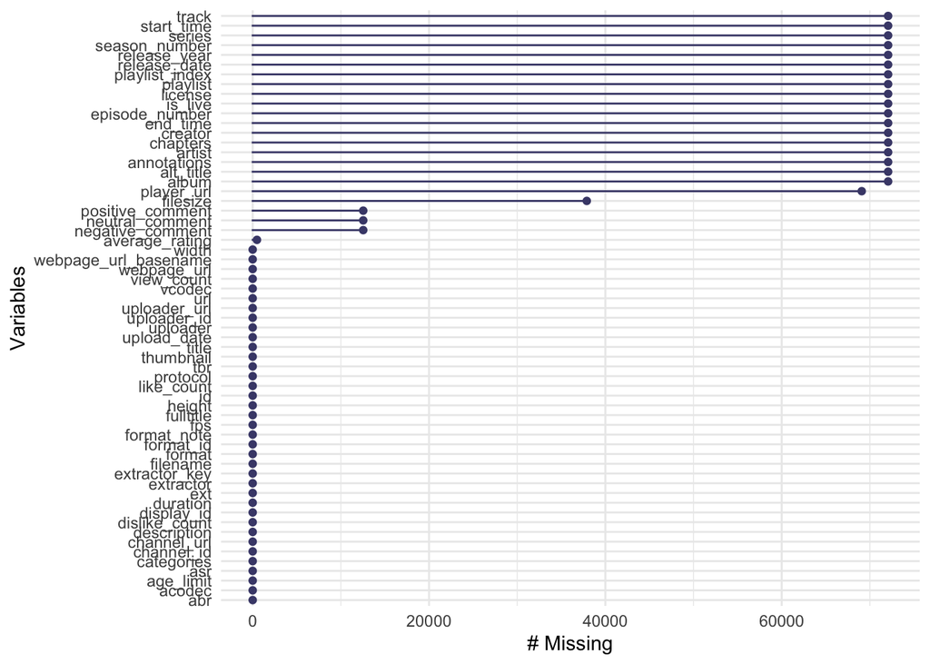

```r
#Plot with missing values from raw data - all the sample
gg_miss_var(df_json_metadata_enrich)
```

### Handling Missing Values and executing PCA

```r
#The first variables have all observations with missing values, so we remove them because they do not add value for the analysis
df_json_metadata_enrich <- select(df_json_metadata_enrich,-c(track,start_time,series,season_number,release_year,release_date,playlist_index,playlist,license,is_live,episode_number,end_time,creator,chapters,artist,annotations,alt_title,album,player_url,filesize))

#We turn the variables that were originally numeric back again into numeric
df_json_metadata_enrich$positive_comment <- as.numeric(df_json_metadata_enrich$positive_comment)
df_json_metadata_enrich$neutral_comment <- as.numeric(df_json_metadata_enrich$neutral_comment)
df_json_metadata_enrich$negative_comment <- as.numeric(df_json_metadata_enrich$negative_comment)
df_json_metadata_enrich$average_rating <- as.numeric(df_json_metadata_enrich$average_rating)
df_json_metadata_enrich$dislike_count <- as.numeric(df_json_metadata_enrich$dislike_count)
df_json_metadata_enrich$like_count <- as.numeric(df_json_metadata_enrich$like_count)
df_json_metadata_enrich$duration <- as.numeric(df_json_metadata_enrich$duration)
df_json_metadata_enrich$format_id <- as.numeric(df_json_metadata_enrich$format_id)
df_json_metadata_enrich$fps <- as.numeric(df_json_metadata_enrich$fps)
df_json_metadata_enrich$height <- as.numeric(df_json_metadata_enrich$height)
df_json_metadata_enrich$view_count <- as.numeric(df_json_metadata_enrich$view_count)
df_json_metadata_enrich$width <- as.numeric(df_json_metadata_enrich$width)

#Keep only the complete cases, removing all rows with at least one NA
df_json_metadata_enrich <- df_json_metadata_enrich[complete.cases(df_json_metadata_enrich),]
#57517 observations
head(df_json_metadata_enrich)
```

| filename | abr | acodec | age_limit | asr | average_rating | categories | channel_id | channel_url | description | dislike_count | display_id | duration | ext | extractor | extractor_key | format | format_id | format_note | fps | fulltitle | height | id | like_count | protocol | tbr | thumbnail | title | upload_date | uploader | … |
| --- | --- | --- | --- | --- | --- | --- | --- | --- | --- | --- | --- | --- | --- | --- | --- | --- | --- | --- | --- | --- | --- | --- | --- | --- | --- | --- | --- | --- | --- | --- |
| C:\\Temp\\youtube\\yt8m\\--7pVHGDdYI.mp4 | 96 | mp4a.40.2 | 0 | 44100 | 5.000000 | Howto & Style | UCTRUipKEXubcWGtg-tluscw | http://www.youtube.com/channel/UCTRUipKEXubcWGtg-tluscw | And you could enter the Wizardy World for FREE! Get the ticket here!\nhttp://PotterSevenHallows.blogspot.com/\n\nGet the ticket to watch Deathly Hallows For FREE! Limited pre-premiere offer!\nGet FREE… | 191 | --7pVHGDdYI | 266 | mp4 | youtube | Youtube | 18 - 480x268 (240p) | 18 | 240p | 30 | Daniel Radcliffe And Rupert Grind Officially Opened Wizardy World At Universal Studios | 268 | --7pVHGDdYI | 2176 | https | 537.239 | https://i.ytimg.com/vi/--7pVHGDdYI/hqdefault.jpg?sqp=-oaymwEZCNACELwBSFXyq4qpAwsIARUAAIhCGAFwAQ==&rs=AOn4CLBV3e9V3C3F64DrvkqI6oBemtBb0g | Daniel Radcliffe And Rupert Grind Officially Opened Wizardy World At Universal Studios | 20101104 | HallowsHarryPotter | … |
| C:\\Temp\\youtube\\yt8m\\--BrlAsOeUY.mp4 | 192 | mp4a.40.2 | 0 | 44100 | 5.000000 | People & Blogs | UCMGY0ZWQmyqHzKZcJXaaxnA | http://www.youtube.com/channel/UCMGY0ZWQmyqHzKZcJXaaxnA | http://www.facebook.com/TheMasterofHoppetsBeerReviews\n\nhttp://twitter.com/#!/MasterofHoppets\n\nInformation About This Beer:\n\nBreweries:Cigar City Brewing\nBeer: Cigar City Hunahpu's Imperial Stou… | 0 | --BrlAsOeUY | 420 | mp4 | youtube | Youtube | 22 - 1280x720 (720p) | 22 | 720p | 30 | TMOH - Beer Review 850#: Cigar City Hunahpu's Imperial Stout | 720 | --BrlAsOeUY | 13 | https | 2513.584 | https://i.ytimg.com/vi/--BrlAsOeUY/maxresdefault.jpg | TMOH - Beer Review 850#: Cigar City Hunahpu's Imperial Stout | 20121017 | The Master of Hoppets | … |
| C:\\Temp\\youtube\\yt8m\\--Dvs2BwOI0.mp4 | 96 | mp4a.40.2 | 0 | 44100 | 4.368421 | Education | UChbmp9N5NttZT3kGlYUzblQ | http://www.youtube.com/channel/UChbmp9N5NttZT3kGlYUzblQ | Comentarios sobre las diferencias entre el SLE Portal y el SLE PLE | 0 | --Dvs2BwOI0 | 141 | mp4 | youtube | Youtube | 18 - 610x360 (360p) | 18 | 360p | 26 | ¿Cuál es la diferencia entre el SLE Portal y el SLE PLE? | 360 | --Dvs2BwOI0 | 24 | https | 266.026 | https://i.ytimg.com/vi/--Dvs2BwOI0/hqdefault.jpg?sqp=-oaymwEZCNACELwBSFXyq4qpAwsIARUAAIhCGAFwAQ==&rs=AOn4CLCBxkJ1cJ0gXwXXUvLEjJ8Y1rieJw | ¿Cuál es la diferencia entre el SLE Portal y el SLE PLE? | 20140521 | Talleres con Dionicio | … |
| C:\\Temp\\youtube\\yt8m\\--EPFZnfHK8.mp4 | 192 | mp4a.40.2 | 0 | 44100 | 4.391305 | Howto & Style | UCCDJt7VUvZx1bWb0-w6gfyQ | http://www.youtube.com/channel/UCCDJt7VUvZx1bWb0-w6gfyQ | Elf Lipstick Seductive\nElf Lipstick Flirtatious\nElf Lipstick Captivating\nElf Lipstick Classy\nElf Lipstick Posh\nElf Lipstick Sociable\n\nPlease like the video, if you enjoyed it. \nDon't forget to… | 3 | --EPFZnfHK8 | 260 | mp4 | youtube | Youtube | 22 - 1280x720 (720p) | 22 | 720p | 30 | ELF Lipstick Collection: Live Swatches & Review | 720 | --EPFZnfHK8 | 16 | https | 999.596 | https://i.ytimg.com/vi/--EPFZnfHK8/hqdefault.jpg?sqp=-oaymwEZCNACELwBSFXyq4qpAwsIARUAAIhCGAFwAQ==&rs=AOn4CLCo0Ee2l2jEkko2F6w8cVEVZ385_Q | ELF Lipstick Collection: Live Swatches & Review | 20130327 | Cheerful Syanu | … |
| C:\\Temp\\youtube\\yt8m\\--Hfol2AEOk.mp4 | 96 | mp4a.40.2 | 0 | 44100 | 4.783393 | People & Blogs | UCbCL_dS_4KjCJ8NKry0wwJQ | http://www.youtube.com/channel/UCbCL_dS_4KjCJ8NKry0wwJQ | http://www.wineriff.com - Paul Sloan from Small Vines Viticulture talks about the importance of shoot positioning that allows the appropriate amount of sunlight to be dispersed on the vines evenly.\r\… | 14 | --Hfol2AEOk | 212 | mp4 | youtube | Youtube | 18 - 640x360 (360p) | 18 | 360p | 30 | Importance of Shoot Positioning | 360 | --Hfol2AEOk | 78 | https | 753.256 | https://i.ytimg.com/vi_webp/--Hfol2AEOk/maxresdefault.webp | Importance of Shoot Positioning | 20100622 | wineriff | … |
| C:\\Temp\\youtube\\yt8m\\--LkgPyiC70.mp4 | 192 | mp4a.40.2 | 0 | 44100 | 4.963303 | Entertainment | UCWgK_4f2rYzU9jUru8-RxTA | http://www.youtube.com/channel/UCWgK_4f2rYzU9jUru8-RxTA | Microsoft Flight Simulator X -\nAmerican Airlines Boeing 757-200 approach, landing and taxi to Luis Muñoz Marín International Airport. Amazing, new scenery by LatinVFR. Nice to see San Juan get a face… | 15 | --LkgPyiC70 | 420 | mp4 | youtube | Youtube | 22 - 1280x720 (720p) | 22 | 720p | 30 | FSX - APPROACH: San Juan, Puerto Rico | 720 | --LkgPyiC70 | 263 | https | 1484.592 | https://i.ytimg.com/vi_webp/--LkgPyiC70/maxresdefault.webp | FSX - APPROACH: San Juan, Puerto Rico | 20140529 | nguyen son tung nguyen | … |

```r
summary(df_json_metadata_enrich)
```

```
   filename             abr               acodec           age_limit
 Length:57517       Length:57517       Length:57517       Length:57517
 Class :character   Class :character   Class :character   Class :character
 Mode  :character   Mode  :character   Mode  :character   Mode  :character



     asr            average_rating   categories         channel_id
 Length:57517       Min.   :1.000   Length:57517       Length:57517
 Class :character   1st Qu.:4.429   Class :character   Class :character
 Mode  :character   Median :4.768   Mode  :character   Mode  :character
                    Mean   :4.554
                    3rd Qu.:4.925
                    Max.   :5.000
 channel_url        description        dislike_count       display_id
 Length:57517       Length:57517       Min.   :    0.00   Length:57517
 Class :character   Class :character   1st Qu.:    1.00   Class :character
 Mode  :character   Mode  :character   Median :    5.00   Mode  :character
                                       Mean   :   54.84
                                       3rd Qu.:   17.00
                                       Max.   :99446.00
    duration          ext             extractor         extractor_key
 Min.   :  56.0   Length:57517       Length:57517       Length:57517
 1st Qu.: 193.0   Class :character   Class :character   Class :character
 Median : 277.0   Mode  :character   Mode  :character   Mode  :character
 Mean   : 287.4
 3rd Qu.: 376.0
 Max.   :4993.0
    format            format_id     format_note             fps
 Length:57517       Min.   :18.00   Length:57517       Min.   : 6.00
 Class :character   1st Qu.:18.00   Class :character   1st Qu.:25.00
 Mode  :character   Median :22.00   Mode  :character   Median :30.00
                    Mean   :20.13                      Mean   :27.61
                    3rd Qu.:22.00                      3rd Qu.:30.00
                    Max.   :22.00                      Max.   :30.00
  fulltitle             height           id              like_count
 Length:57517       Min.   : 88.0   Length:57517       Min.   :     0.0
 Class :character   1st Qu.:360.0   Class :character   1st Qu.:    16.0
 Mode  :character   Median :720.0   Mode  :character   Median :    56.0
                    Mean   :541.6                      Mean   :   866.7
```

[output cut: 22 more lines]

```
                                       Max.   :205174313
 webpage_url_basename     width        positive_comment neutral_comment
 Length:57517         Min.   : 128.0   Min.   : 0.000   Min.   : 0.000
 Class :character     1st Qu.: 492.0   1st Qu.: 0.000   1st Qu.: 1.000
 Mode  :character     Median :1280.0   Median : 3.000   Median : 3.000
                      Mean   : 922.9   Mean   : 8.581   Mean   : 6.828
                      3rd Qu.:1280.0   3rd Qu.:13.000   3rd Qu.: 9.000
                      Max.   :1280.0   Max.   :50.000   Max.   :50.000
 negative_comment
 Min.   : 0.000
 1st Qu.: 0.000
 Median : 1.000
 Mean   : 2.244
 3rd Qu.: 3.000
 Max.   :44.000
```

### Finally, executing PCA

```r
set.seed(777)
#Sampling the dataset in order to try and be capable of executing the pca (2% of the dataset, approx 1150 random records)
pca_sample <- sample(seq_len(nrow(df_json_metadata_enrich)),size = nrow(df_json_metadata_enrich)*0.02)
df_json_metadata_enrich_sample <- df_json_metadata_enrich[pca_sample,]

#Attempt with PCAmix, used for mixed data
#https://cran.r-project.org/web/packages/PCAmixdata/vignettes/PCAmixdata.html
split <- splitmix(df_json_metadata_enrich_sample)
X1 <- split$X.quanti
X2 <- split$X.quali
# Some of the columns have identical values, which was causing the error "There are columns in X.quali where all the categories are identical". So we decided to remove the columns from the analysis.
X2 <- select(X2, -c(acodec,age_limit,asr,ext,extractor,extractor_key,protocol))

res.pcamix <- PCAmix(X.quanti=X1, X.quali=X2,rename.level=TRUE,graph=FALSE)

res.pcamix$eig
```

```
         Eigenvalue Proportion  Cumulative
dim 1      23.82231 0.12466541   0.1246654
dim 2      19.24171 0.10069450   0.2253599
dim 3      19.01001 0.09948199   0.3248419
dim 4      18.83802 0.09858191   0.4234238
dim 5      18.58427 0.09725403   0.5206778
dim 6      18.44360 0.09651787   0.6171957
dim 7      18.35522 0.09605536   0.7132511
dim 8      18.29037 0.09571600   0.8089671
dim 9      18.24906 0.09549982   0.9044669
dim 10     18.20072 0.09524684   0.9997137
dim 11     18.17762 0.09512597   1.0948397
dim 12     18.16166 0.09504246   1.1898822
dim 13     18.15817 0.09502420   1.2849064
dim 14     18.12280 0.09483909   1.3797455
dim 15     18.10527 0.09474735   1.4744928
dim 16     18.09143 0.09467490   1.5691677
dim 17     18.08368 0.09463434   1.6638020
dim 18     18.05857 0.09450295   1.7583050
dim 19     18.05388 0.09447843   1.8527834
dim 20     18.03583 0.09438396   1.9471674
dim 21     18.03126 0.09436005   2.0415274
dim 22     18.01446 0.09427212   2.1357996
dim 23     18.00761 0.09423626   2.2300358
dim 24     18.00180 0.09420585   2.3242417
dim 25     18.00052 0.09419915   2.4184408
dim 26     18.00000 0.09419646   2.5126373
dim 27     18.00000 0.09419645   2.6068337
dim 28     17.99992 0.09419606   2.7010298
dim 29     17.99811 0.09418658   2.7952164
dim 30     17.98924 0.09414012   2.8893565
dim 31     17.98329 0.09410899   2.9834655
dim 32     17.96908 0.09403465   3.0775001
dim 33     17.96354 0.09400567   3.1715058
dim 34     17.95284 0.09394968   3.2654555
dim 35     17.93764 0.09387012   3.3593256
dim 36     17.92949 0.09382745   3.4531530
dim 37     17.92682 0.09381349   3.5469665
dim 38     17.92075 0.09378171   3.6407482
dim 39     17.89962 0.09367117   3.7344194
```

[output cut: 1095 more lines]

```
dim 1135   11.55653 0.06047688  99.1703870
dim 1136   11.54992 0.06044231  99.2308293
dim 1137   11.51367 0.06025261  99.2910819
dim 1138   11.50776 0.06022165  99.3513036
dim 1139   11.45970 0.05997018  99.4112737
dim 1140   11.45555 0.05994847  99.4712222
dim 1141   11.45326 0.05993648  99.5311587
dim 1142   11.44773 0.05990753  99.5910662
dim 1143   11.44124 0.05987358  99.6509398
dim 1144   11.37953 0.05955061  99.7104904
dim 1145   11.30463 0.05915869  99.7696491
dim 1146   11.29327 0.05909923  99.8287483
dim 1147   11.00234 0.05757672  99.8863250
dim 1148   11.00180 0.05757391  99.9438990
dim 1149   10.72035 0.05610105 100.0000000
```

[figure not shown]

```r
par(mfrow=c(2,2))
plot(res.pcamix,choice="ind",label=FALSE, posleg="bottomright", main="Observations")
plot(res.pcamix,choice="levels",xlim=c(-1.5,2.5), main="Levels")
plot(res.pcamix,choice="cor",main="Numerical variables")
plot(res.pcamix,choice="sqload",coloring.var=T, leg=TRUE, posleg="topright", main="All variables")
```

```r
#Screeplot
plot(res.pcamix$eig[,1],type="l",main="Screeplot")

#Attempt with PCA from FactoMineR. All the qualitative variables were assigned as qualitative suplementary. Otherwise it was causing an issue with the function.
res.pca <- PCA(df_json_metadata_enrich_sample,quali.sup = c(1,2,3,4,5,7,8,9,10,12,14,15,16,17,19,21,23,25,26,27,28,29,30,31,32,33,34,36,37),scale.unit = FALSE, graph=FALSE)

res.pca$var$cor[,1:2]
```

```
                        Dim.1         Dim.2
average_rating   -0.004282387 -3.642558e-02
dislike_count     0.815710406  3.377768e-01
duration         -0.026135423  1.096465e-02
format_id        -0.069470086 -3.228260e-02
fps               0.013539392 -3.120409e-02
height           -0.074047329 -4.768712e-02
like_count        0.547385783  8.368801e-01
view_count        1.000000000 -2.747029e-05
width            -0.060717285 -4.393683e-02
positive_comment -0.020105078  4.642215e-02
neutral_comment  -0.019016684  1.895262e-02
negative_comment -0.011904045  1.846028e-02
```

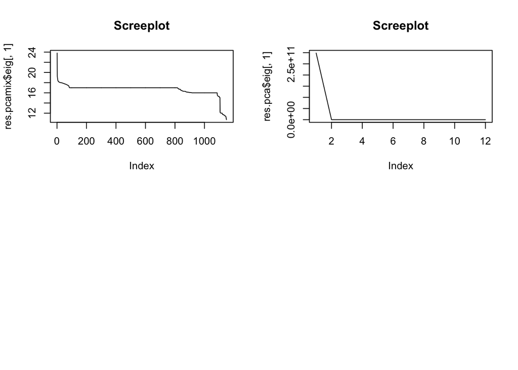

```r
plot(res.pca$eig[,1],type="l",main="Screeplot")
```

## Attempt 2

> This attempt was the one we considered successful, finally the one used for the project to define the global score

```r
pca_data <- read.xlsx(file=paste0(root_path,"conjoint_data.xlsx"),2)
head(pca_data)
```

|  | VideoId | AuthorId | ScoreVideo | ScoreChannel | DislikeCountVideo | LikeCountVideo | ViewCount | SentimentPositiveVideo | SentimentNegativeVideo |
| --- | --- | --- | --- | --- | --- | --- | --- | --- | --- |
| 1 | 13 | 31350 | 0.0525796636939049 | 0.0352864377200603 | 25 | 58 | 52502 | 1 | 0 |
| 2 | 33 | 46628 | 0.117419771850109 | 0.117419771850109 | 7 | 41 | 25954 | 16 | 12 |
| 3 | 37 | 61608 | 0.0181526970118284 | 0.0139350574463606 | 10 | 33 | 13200 | 12 | 0 |
| 4 | 51 | 7560 | 0.0261459946632385 | 0.0261459946632385 | 1 | 4 | 2191 | 1 | 0 |
| 5 | 73 | 51652 | 0.00824323389679193 | 0.0107408985495567 | 208 | 8816 | 896871 | 23 | 4 |
| 6 | 125 | 6643 | 0.0166293233633041 | 0.0350789204239845 | 11 | 77 | 19779 | 3 | 0 |

```r
pca_data <- pca_data %>% dplyr::rename(video_id = VideoId)

#Converting ScoreVideo and ScoreChannel to numeric. Both data were character in excel
pca_data$ScoreVideo <- as.numeric(pca_data$ScoreVideo)
pca_data$ScoreChannel <- as.numeric(pca_data$ScoreChannel)
pca_data$SentimentPositiveVideo <- as.numeric(pca_data$SentimentPositiveVideo)

#2 steps executed in this pipeline: Calculate the LikeDislikeScore and SentimentScore and normalize the data to a maximum of 100
pca_data_enrich <- pca_data  %>% mutate(LikeDislikeScore=(LikeCountVideo-DislikeCountVideo)/ViewCount) %>% mutate(SentimentScore = (SentimentPositiveVideo - SentimentNegativeVideo)/ViewCount) %>% BBmisc::normalize(method = "range",range = c(0,100))
summary(pca_data_enrich)
```

```
    video_id         AuthorId        ScoreVideo       ScoreChannel
 Min.   :  0.00   Min.   :  0.00   Min.   :  0.000   Min.   :  0.000
 1st Qu.: 25.51   1st Qu.: 28.89   1st Qu.:  3.081   1st Qu.:  3.001
 Median : 52.39   Median : 52.43   Median :  5.300   Median :  5.550
 Mean   : 51.12   Mean   : 52.78   Mean   :  8.266   Mean   :  8.513
 3rd Qu.: 76.67   3rd Qu.: 77.28   3rd Qu.: 10.014   3rd Qu.: 10.787
 Max.   :100.00   Max.   :100.00   Max.   :100.000   Max.   :100.000
 DislikeCountVideo   LikeCountVideo        ViewCount
 Min.   :  0.00000   Min.   :  0.00000   Min.   :  0.00000
 1st Qu.:  0.02119   1st Qu.:  0.01488   1st Qu.:  0.03001
 Median :  0.10595   Median :  0.05207   Median :  0.10498
 Mean   :  0.67944   Mean   :  0.61656   Mean   :  0.73773
 3rd Qu.:  0.31786   3rd Qu.:  0.19302   3rd Qu.:  0.34869
 Max.   :100.00000   Max.   :100.00000   Max.   :100.00000
 SentimentPositiveVideo SentimentNegativeVideo LikeDislikeScore
 Min.   :  0.000        Min.   :  0.000        Min.   :  0.00
 1st Qu.:  0.000        1st Qu.:  0.000        1st Qu.: 12.49
 Median :  6.383        Median :  3.125        Median : 13.24
 Mean   : 17.913        Mean   :  7.750        Mean   : 15.03
 3rd Qu.: 29.787        3rd Qu.:  9.375        3rd Qu.: 15.10
 Max.   :100.000        Max.   :100.000        Max.   :100.00
 SentimentScore
 Min.   :  0.00
 1st Qu.: 10.08
 Median : 10.39
 Mean   : 11.80
 3rd Qu.: 11.66
 Max.   :100.00
```

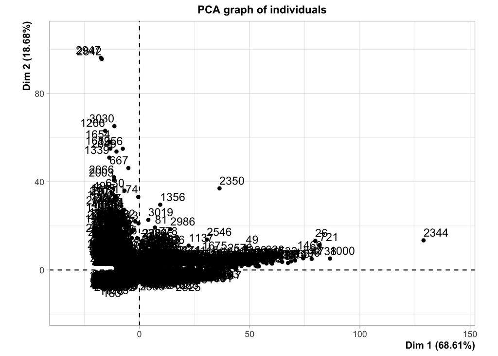

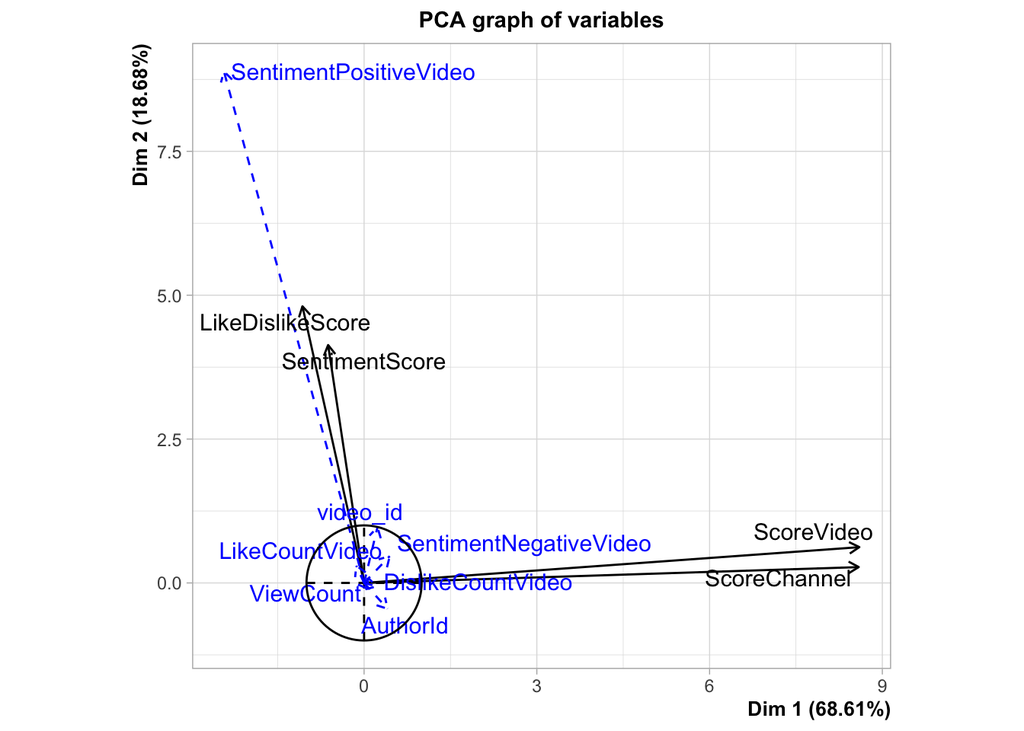

```r
#Execution of PCA function
# Scale = FALSE
res.pca.attempt2.scale.false <- PCA(pca_data_enrich,quanti.sup = c(1:2,5:9),scale.unit = FALSE)
```

```r
#Print the first principal component
res.pca.attempt2.scale.false$svd$V[,1]
```

```
[1]  0.70389460  0.70302449 -0.08760328 -0.05113337
```

```r
# Scale = TRUE - Disregarded
#res.pca.attempt2.scale.false <- PCA(pca_data_enrich,quanti.sup = c(1:2,5:9),scale.unit = FALSE)
#Print the first principal component
#res.pca.attempt2.scale.false$svd$V[,1]
```